# 準備

```r
# データの加工用ライブラリ
library(stringr)
library(dplyr)

# ラスターの加工用ライブラリ
library(raster)
library(sf)
library(lattice)
library(rasterVis)
library(RColorBrewer)

# 種分布モデリング (MaxEnt) 実行用ライブラリ
## 実行にはパスを通すなどの処理が必要になる。
library(SDMtune)
library(rJava)
library(dismo)
```

```r
mesh2get <- function(x, y){
    p <- (y * 60) %/% 40
    a <- (y * 60) %% 40
    u <- (x - 100) %/% 1
    f <- (x - 100) %% 1
    q <- a %/% 5
    b <- a %% 5
    v <- (f * 60) %/% 7.5
    g <- (f * 60) %% 7.5

    p * 10000 + u * 100 + q * 10 + v * 1
}

latget <- function(mesh2){
    trunc(mesh2 / 10000) * 2/3 + trunc(mesh2 %% 100 / 10) * 2/3 / 8
}
longet <- function(mesh2){
    100 + trunc((mesh2 - trunc(mesh2 / 10000)*10000) / 100) + mesh2 %% 10 / 8
}

pal<- c("#220d3d", "#729696", "#9EBE91", "#E4B80E", "#ff0000","#f20085")
```

```r
env_data <- read.csv("C:/Users/ikari/Documents/laboratory/projects/202210_seminar/data/terrestrial_environment_grid10km.csv")

tempdf <- data.frame("name"=NA, "isContinuous"=NA)[-1,]
for (ii in 5:ncol(env_data)){
    tempdf <- rbind(tempdf, data.frame("name"=colnames(env_data)[ii], "isContinuous"=(length(unique(env_data[,c(ii)]))/length(env_data[,c(ii)]) > 0.3)))
}
tempdf[tempdf$isContinuous==FALSE,]
# 値のバリエーションが少ない変数は、カテゴリカル変数かも
```

A data.frame: 4 × 2

|  | name <chr> | isContinuous <lgl> |
| --- | --- | --- |
| 40 | beach_2014 | FALSE |
| 58 | Allu | FALSE |
| 61 | running_water_num | FALSE |
| 63 | water_stagnation_num | FALSE |

```r
## 環境データのラスター化
for (ii in 4:ncol(env_data)){
    assign(colnames(env_data)[ii], rasterFromXYZ(env_data[,c(2,3,ii)]))
}

for(ii in 4:ncol(env_data)){
    if(ii == 4){
                xy2 = get(colnames(env_data)[ii])
            } else {
                xy2 = stack(xy2,get(colnames(env_data)[ii]))
    }
}

crs(xy2) = "+proj=longlat +datum=WGS84 +no_defs +ellps=WGS84 +towgs84=0,0,0"

crs(xy2) = "+proj=longlat +datum=WGS84 +no_defs +ellps=WGS84 +towgs84=0,0,0"

OCC_DATA <- read.csv("C:/Users/ikari/Documents/laboratory/projects/202210_seminar/data/amphibian_grid10km.csv")
OCC_DATA <- OCC_DATA[OCC_DATA$Category=="nat.",]
sps_list <- unique(OCC_DATA$species)
```

```r
names(xy2)
```

1. 'elevation'

2. 'elevationSD'

3. 'slope'

4. 'orc'

5. 'cec'

6. 'ph'

7. 'land.area'

8. 'bio_1'

9. 'bio_2'

10. 'bio_3'

11. 'bio_4'

12. 'bio_5'

13. 'bio_6'

14. 'bio_7'

15. 'bio_8'

16. 'bio_9'

17. 'bio_10'

18. 'bio_11'

19. 'bio_12'

20. 'bio_13'

21. 'bio_14'

22. 'bio_15'

23. 'bio_16'

24. 'bio_17'

25. 'bio_18'

26. 'bio_19'

27. 'radiation'

28. 'laplacian'

29. 'sunshine'

30. 'snow'

31. 'sea.distance'

32. 'hii'

33. 'city.area_2014'

34. 'cult_2014'

35. 'natural_2014'

36. 'Ngrass_2014'

37. 'second_2014'

38. 'Sgrass_2014'

39. 'farmland_2014'

40. 'water.area_2014'

41. 'beach_2014'

42. 'wasteland_2014'

43. 'city.area5_2014'

44. 'water.area5_2014'

45. 'beach5_2014'

46. 'wasteland5_2014'

47. 'rice.field5_2014'

48. 'natural5_2014'

49. 'cult5_2014'

50. 'second5_2014'

51. 'Ngrass5_2014'

52. 'Sgrass5_2014'

53. 'farmland5_2014'

54. 'roadDIST'

55. 'roadLENGTH'

56. 'populatin'

57. 'pop_density'

58. 'WC_area'

59. 'Allu'

60. 'river_length'

61. 'running_water_area'

62. 'running_water_num'

63. 'water_stagnation_area'

64. 'water_stagnation_num'

65. 'rice.field_2014'

66. 'headstream_dist'

67. 'rivermouth_dist'

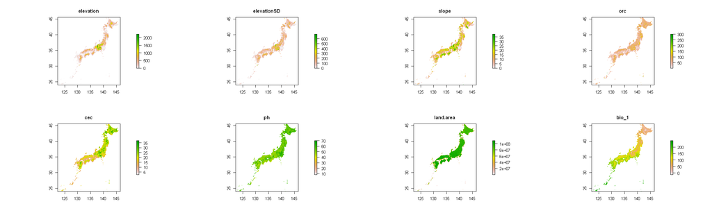

```r
par(mar=c(5, 4, 4, 4) + 0.1)
par(mgp=c(2.5, 1, 0))

par(mfrow = c(2, 4))
options(repr.plot.width=20, repr.plot.height=6)

for(i in 1:8){

    plot(xy2[[i]])
    title(main=names(xy2)[i], line=1)
}
par(mfrow = c(1, 1))

# 最初の8つをプロット
```

```r
data_use <-  OCC_DATA[, c("species", "longitude", "latitude", "mesh2")]

taxon <- "Rhacophorus arboreus"

data_xy <- subset(data_use, data_use$species==taxon)
data_xy <- data_xy[!duplicated(data_xy$mesh2), c(2,3)]
colnames(data_xy) <- c("x", "y")
```

# MaxEnt実行

```r
bg_xy <-sample_n(tbl = env_data[, c(2,3)], size = 1000)
colnames(bg_xy) <- c("x", "y")
data <- prepareSWD(species = taxon, p = data_xy, a = bg_xy, env = xy2)
```

```
Extracting predictor information for presence locations...

Extracting predictor information for absence/background locations...
```

```r
# 分布モデルの学習
model <- train(method = "Maxent", data = data, iter=1000)
```

```
This is MaxEnt version 3.4.4
```

```r
# 学習データ点での生息適度予測値を計算
pred <- predict(model, data = data, type = "cloglog")
```

```r
# 生息適度予測値を全グリッドで計算
map <- predict(model, data = xy2, type = "cloglog")
names(map) <- taxon
```

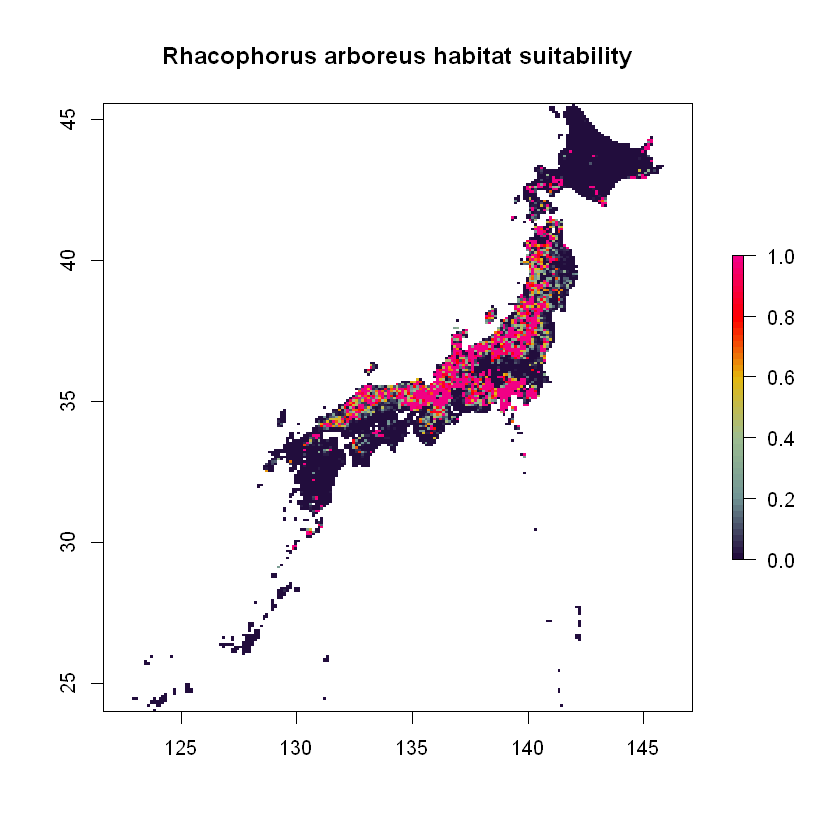

```r
options(repr.plot.width=7, repr.plot.height=7)
plot(map, col=colorRampPalette(pal)(50))
title(paste(taxon, "habitat suitability"))
```

```r
# スキル統計量最大化による閾値選択
ths <- thresholds(model, type = "cloglog")[3,2]

binary_map <- map
names(binary_map) <- taxon

binary_map[binary_map[] < ths] <- 0
binary_map[binary_map[] >= ths] <- 1
```

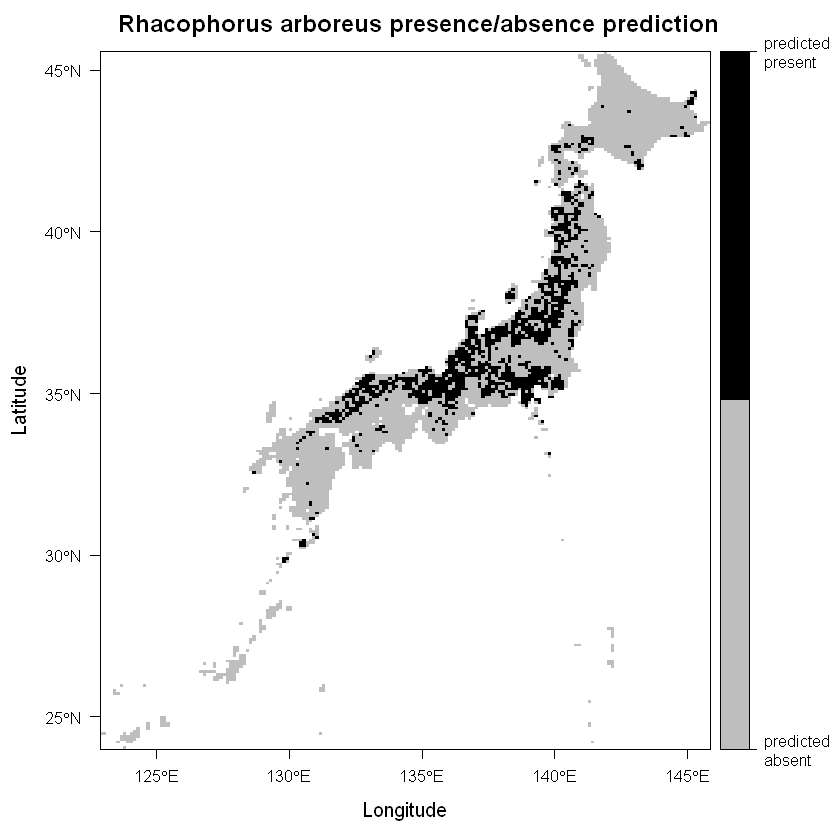

```r
rasterVis::levelplot(binary_map,at=c(0,0.5,1),main=paste(taxon, "presence/absence prediction"),
                     margin=FALSE,colorkey=list(labels=list(at=c(0, 1), labels=c("predicted\nabsent", "predicted\npresent"))), col.regions=c("grey", "black"))
```

# モデルの評価

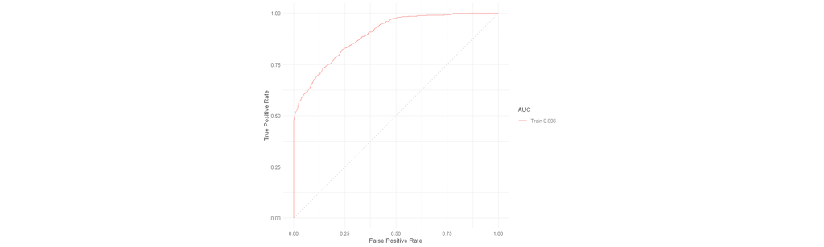

```r
plotROC(model)
```

↑  
**x軸**：在予測されたメッシュのうち、「そのメッシュには在記録はない」割合  
「在記録がない」を疑似的に不在メッシュとみなして値を算出しているが、必ずしもそのようなメッシュで「不在」であると解釈されるわけではない。

**y軸**：在予測されたメッシュのうち、「そのメッシュに在記録がある」割合

閾値を1つ決めると、点が1つ得られる。曲線は、閾値を様々に変化させたときの軌跡

AUCは、ROCの下側の面積の大きさを表す。1.0に近いほど、モデルの性能が良いことを示す。

```r
auc(model)
```

0.896180960548885

```r
names(ths) <- "Threshold under max TSS"
ths
```

**Threshold under max TSS:** 0.464389113019764

変数選択を行う目的で、複数のモデルを比較する際にはAICcを用いることもできるが、あまり使わない。

```r
aicc(model, env = xy2)
```

17213.294495181

## 交差検証

```r
folds <- randomFolds(data, k = 4, only_presence = TRUE, seed = 25)
```

```r
cv_model <- train("Maxent", data = data, folds = folds)
cv_model
```

[output not shown]

```r
temp <- c(auc(cv_model), auc(cv_model, test = TRUE))
names(temp) <- c("Mean of AUC of training data across CV", "Mean of AUC of test data across CV")
temp
```

**Mean of AUC of training data across CV**

0.902905123141385

**Mean of AUC of test data across CV**

0.826133833254606

↑交差検証の各試行に対して、AUCを計算して平均。それなりに高いスコアになっている

# coding: shogo ikari 20221022